# Final Project

Allison Tessman

2024-04-26

Subset the data:

1. Bigrams Analysis (Assignment 12)

Do the following:

- Create a list of pairs of words that may contain stopwords and plot the most frequent pairs.
- Create a list of pairs of words that do not contain stopwords and plot the most frequent pairs.
- Visualize the pairs of words (bigrams)
- Plot the context sentiment analysis

```r
library(tidyverse)
df <- read_csv("~/Applied Analystics SAS Prog/mymath475/final_complaints.csv")
```

```r
# subset the first 500 rows of the data
df = df[c(1:500),]

# OR

# a random sample of 500 rows from the data
#df = df[sample(nrow(df), 500),]

# only look at sub product with most reviews
library(tidyverse)
library(ggplot2)
library(tidytext)
library(tm)
df %>%
  group_by(`Sub-issue`) %>%
  count(sort = TRUE)
```

```
## # A tibble: 52 × 2
## # Groups:   Sub-issue [52]
##    `Sub-issue`                                                  n
##    <chr>                                                    <int>
##  1 Information belongs to someone else                         98
##  2 Reporting company used your report improperly               87
##  3 Their investigation did not fix an error on your report     72
##  4 Account status incorrect                                    28
##  5 Account information incorrect                               24
##  6 Deposits and withdrawals                                    19
##  7 Investigation took more than 30 days                        19
##  8 Credit inquiries on your report that you don't recognize    16
##  9 Was not notified of investigation status or results         12
## 10 Transaction was not authorized                              11
## # ℹ 42 more rows
```

```r
# filter out to only include credit reporting (#1 complaints)
df = df %>%
  select(`Sub-issue`, `Consumer complaint narrative`) %>%
  filter(`Sub-issue`=='Information belongs to someone else') %>%
  rename(texts = `Consumer complaint narrative`)

# create a list of pairs of words
df_bigrams <- df %>%
  unnest_tokens(input = texts, output = bigram, token = "ngrams", n = 2) %>%
  filter(!is.na(bigram))

df_bigrams %>%
  count(bigram, sort = TRUE)
```

```
## # A tibble: 5,638 × 2
##    bigram             n
##    <chr>          <int>
##  1 xxxx xxxx       2938
##  2 xx xx            218
##  3 xx xxxx          195
##  4 xxxx xx          120
##  5 i have           101
##  6 identity theft    97
##  7 xxxx balance      85
##  8 my credit         83
##  9 i am              82
## 10 of the            76
## # ℹ 5,628 more rows
```

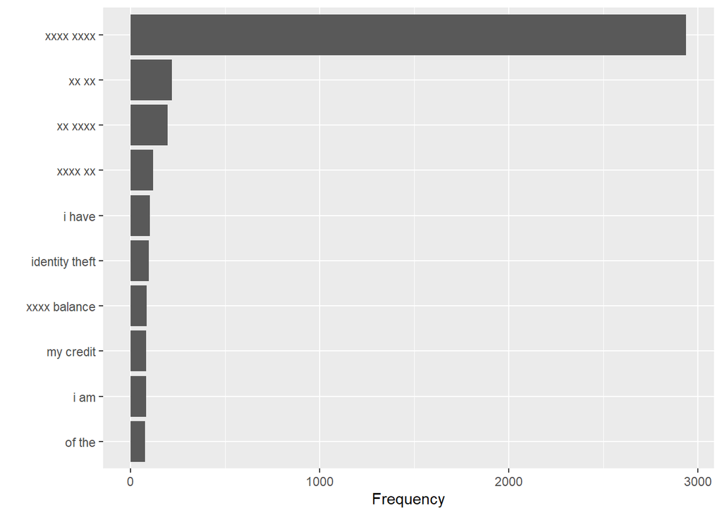

```r
# top most frequent pairs
df_bigrams %>%
  count(bigram, sort = TRUE) %>%
  head(10) %>%
  ggplot(aes(x = n, y = reorder(bigram, n))) +
  geom_col() +
  labs(y = '', x = 'Frequency')
```

```r
# remove stop words
bigrams_separated <- df_bigrams %>%
    separate(bigram, c("word1", "word2"), sep = " ")

stop_word2 = tibble(word = c(letters, LETTERS, "oh", 'just', 'xxxx', 'xx'))

bigrams_filtered <- bigrams_separated %>%
    filter(!word1 %in% stop_words$word) %>%
    filter(!word1 %in% stop_words$word) %>%
    filter(!word1 %in% stop_word2$word) %>%
    filter(!word2 %in% stop_word2$word)

# new bigram counts:
bigram_counts <- bigrams_filtered %>%
    count(word1, word2, sort = TRUE)
bigram_counts
```

```
## # A tibble: 2,432 × 3
##    word1     word2         n
##    <chr>     <chr>     <int>
##  1 identity  theft        97
##  2 credit    reporting    57
##  3 credit    report       48
##  4 victim    of           45
##  5 date      of           42
##  6 credit    bureaus      40
##  7 consumer  reporting    37
##  8 reporting agency       37
##  9 section   605b         36
## 10 balance   0.00         34
## # ℹ 2,422 more rows
```

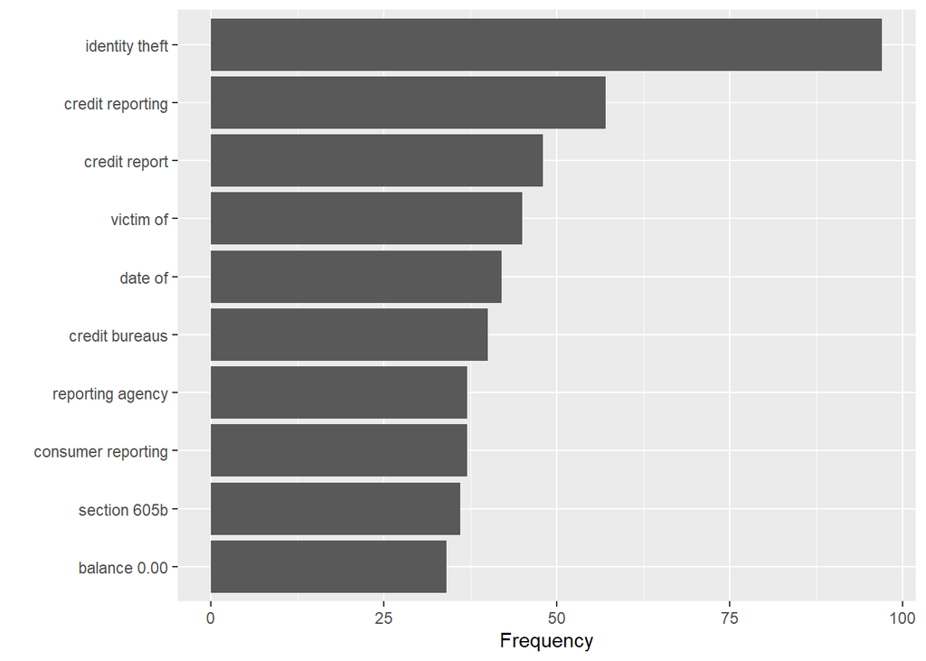

```r
# top most frequent pairs
bigram_counts$pairs = paste0(bigram_counts$word1, " ", bigram_counts$word2)

bigram_counts %>%
  head(10) %>%
  ggplot(aes(x = n, y = reorder(pairs, n))) +
  geom_col() +
  labs(y = '', x = 'Frequency')
```

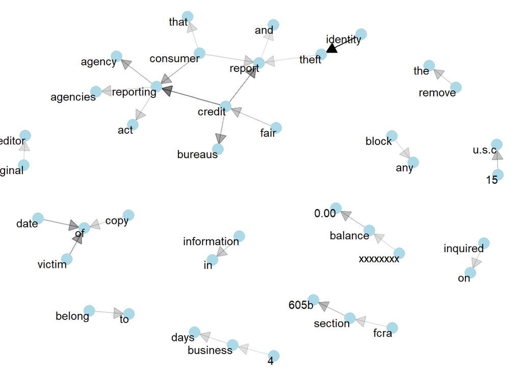

```r
# visualize the bigrams
library(igraph)
bigram_graph <- bigram_counts %>%
  filter(n > 20) %>%
  graph_from_data_frame()

library(ggraph)
set.seed(2024)

a <- grid::arrow(type = "closed", length = unit(.15, "inches"))

ggraph(bigram_graph, layout = "fr") +
  geom_edge_link(aes(edge_alpha = n), show.legend = FALSE,
                 arrow = a, end_cap = circle(.07, 'inches')) +
  geom_node_point(color = "lightblue", size = 5) +
  geom_node_text(aes(label = name), vjust = 1, hjust = 1) +
  theme_void()
```

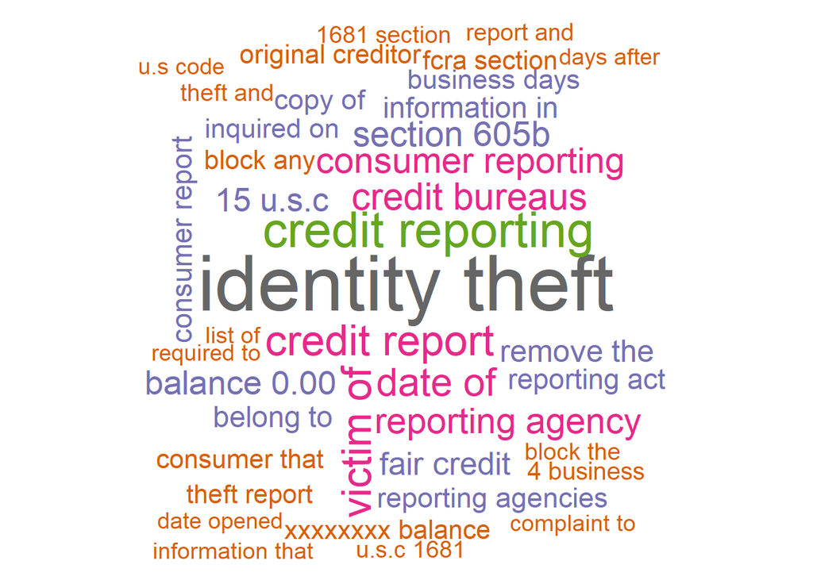

```r
# create a wordcloud
## create a wordcloud
library(wordcloud)
bigram_counts %>%
  with(wordcloud(pairs, n, random.order = FALSE,
                 max.words = 40,
                 colors=brewer.pal(8,"Dark2")))
```

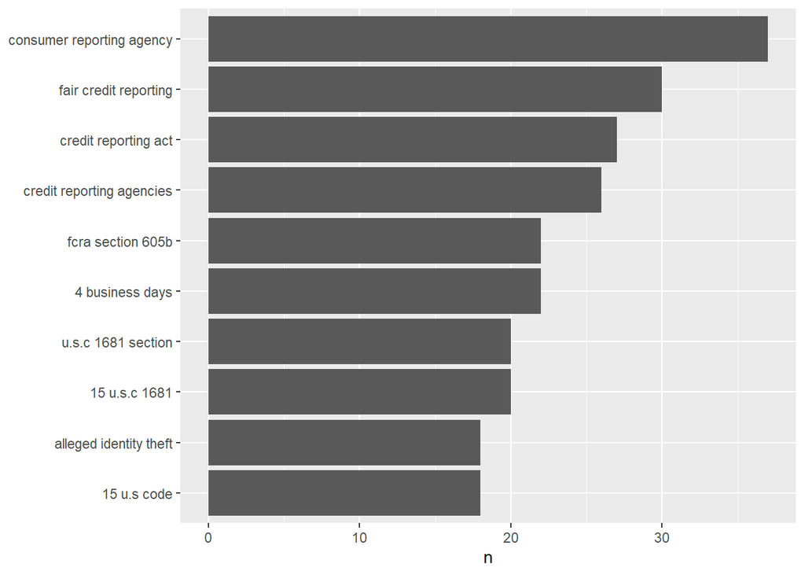

```r
# *********************************************

# Trigrams
df_trigrams <- df %>%
  unnest_tokens(input = texts, output = trigram, token = "ngrams", n = 3) %>%
  filter(!is.na(word))

df_separated <- df_trigrams %>%
    separate(trigram, c("word1", "word2", "word3"), sep = " ")

stop_word3 = tibble(word = c(letters, LETTERS, "oh", 'just', 'xxxx', 'xx'))

df_filtered <- df_separated %>%
    filter(!word1 %in% stop_words$word) %>%
    filter(!word2 %in% stop_words$word) %>%
    filter(!word3 %in% stop_words$word) %>%
    filter(!word1 %in% stop_word3$word) %>%
    filter(!word2 %in% stop_word3$word) %>%
    filter(!word3 %in% stop_word3$word)

trigram_count <- df_filtered %>%
  count(word1, word2, word3, sort = TRUE) %>%
  unite(word, word1, word2, word3, sep = " ")

## plot the frequency
trigram_count %>%
  filter(n > 15) %>%
  mutate(word = reorder(word, n)) %>%
  ggplot(aes(word, n)) +
  geom_col() +
  xlab(NULL) +
  coord_flip()
```

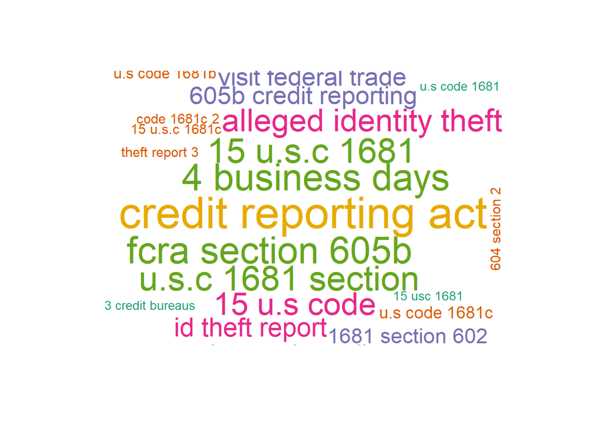

```r
# wordcloud
trigram_count %>%
  with(wordcloud(word, n, random.order = FALSE,
                 max.words = 50, colors=brewer.pal(8,"Dark2")))
```

```r
# ***********************************************

# Content Sentiment Analysis

# words preceded by NOT
bigrams_separated %>%
  filter(word1 == "not") %>%
  count(word1, word2, sort = TRUE)
```

```
## # A tibble: 69 × 3
##    word1 word2          n
##    <chr> <chr>      <int>
##  1 not   belong        26
##  2 not   later         20
##  3 not   a             16
##  4 not   furnish       12
##  5 not   been           8
##  6 not   mine           6
##  7 not   reporting      6
##  8 not   be             5
##  9 not   my             5
## 10 not   understand     5
## # ℹ 59 more rows
```

```r
AFINN <- get_sentiments("afinn")

not_words <- bigrams_separated %>%
  filter(word1 == "not") %>%
  inner_join(AFINN, by = c(word2 = "word")) %>%
  count(word2, value, sort = TRUE)

not_words
```

```
## # A tibble: 5 × 3
##   word2     value     n
##   <chr>     <dbl> <int>
## 1 accepting     1     2
## 2 agree         1     1
## 3 block        -1     1
## 4 help          2     1
## 5 true          2     1
```

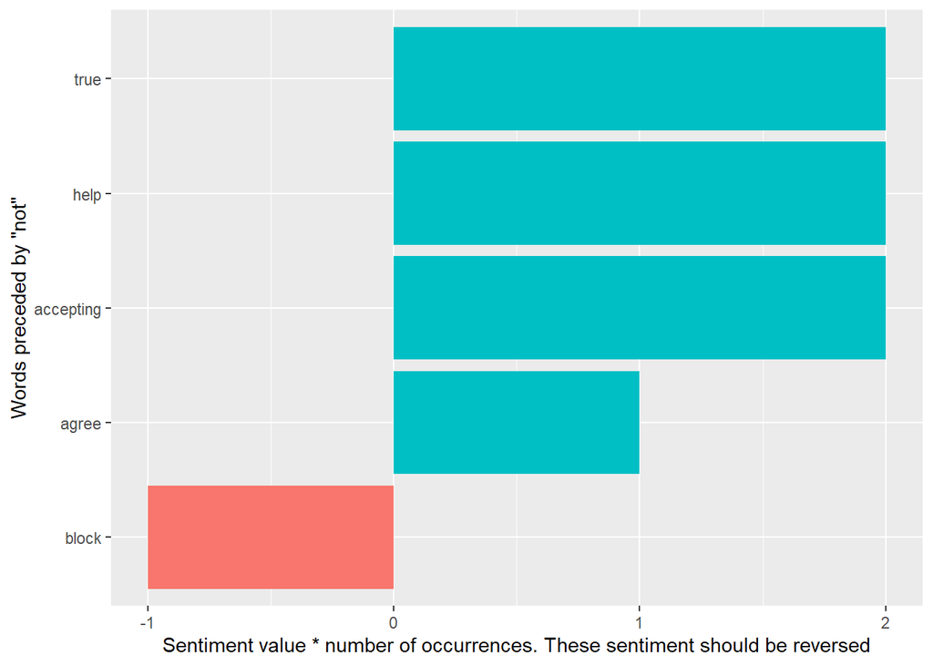

```r
# plot sentiment analysis
# NOTE: use of word NOT can cause reversed sentiment and is issue
library(ggplot2)

not_words %>%
  mutate(contribution = n * value) %>%
  arrange(desc(abs(contribution))) %>%
  head(20) %>%
  mutate(word2 = reorder(word2, contribution)) %>%
  ggplot(aes(n * value, word2, fill = n * value > 0)) +
  geom_col(show.legend = FALSE) +
  labs(x = "Sentiment value * number of occurrences. These sentiment should be reversed",
       y = "Words preceded by \"not\"")
```

```r
# identify words that connect with not, no, never, without
# then reverse the sentiment values of these words
stop_word2 = tibble(word = c(letters, LETTERS, "oh", 'just', 'xx', 'xxxx'))
AFINN <- get_sentiments("afinn")

sentiment1 = df %>%
  unnest_tokens(input = texts, output = word) %>%
  anti_join(get_stopwords()) %>%
  anti_join(stop_word2) %>%
  inner_join(get_sentiments("afinn")) %>%
  filter(!is.na(value)) %>%
  count(value)
```

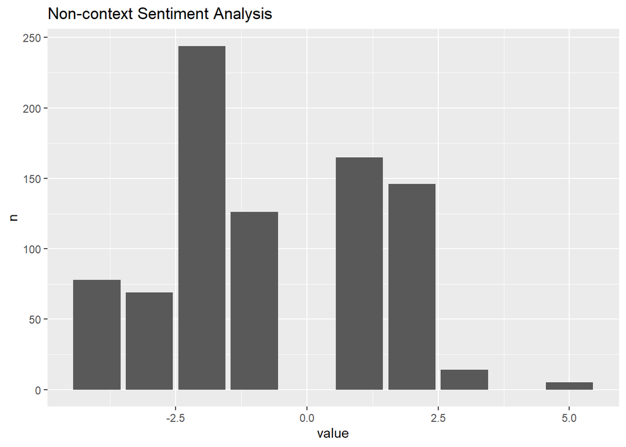

```r
sentiment1 %>%
  ggplot(aes(x = value, y = n))+
  geom_col()+
  labs(title = 'Non-context Sentiment Analysis')
```

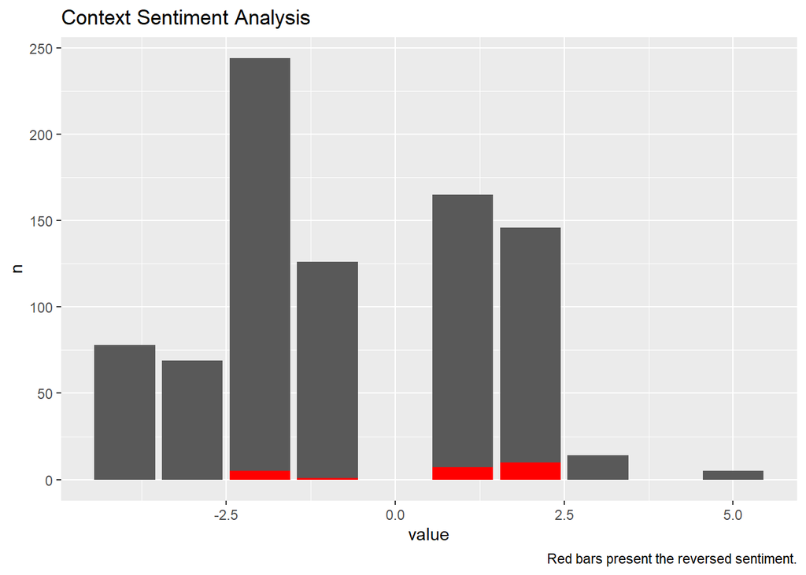

```r
negation_words <- c("not", "no", "never", "without")

sentiment2 = bigrams_separated %>%
  filter(word1 %in% negation_words) %>%
  inner_join(AFINN, by = c(word2 = "word")) %>%
  count(word1, word2, value, sort = TRUE) %>%
  select(value, n) %>%
  group_by(value) %>%
  summarise(n = sum(n)) %>%
  arrange(value)

ggplot()+
  geom_col(data = sentiment1, aes(x =value, y = n))+
  geom_col(data = sentiment2, aes(x =value, y = n), fill = 'red')+
  labs(title = 'Context Sentiment Analysis',
       caption = "Red bars present the reversed sentiment.")
```

```r
# Red bars present the reversed sentiment!
```

2. Word Pair and Correlation Analysis (Assignment 13)

Do the following:

- Create a list of all possible pairs of words (not only adjacent words) that do not contain stopwords and plot the most frequent pairs.
- Plot the graph of the pairs of words
- Compute the correlations of all the pairs and plot the bar chart of the pairs with the highest correlation
- Plot the graph of the correlation

```r
library(tidyverse)

df <- read_csv("~/Applied Analystics SAS Prog/mymath475/final_complaints.csv")
# subset the first 500 rows of the data
df = df[c(1:500),]

# OR

# a random sample of 500 rows from the data
#df = df[sample(nrow(df), 500),]


# Find item with most reviews
df %>%
  group_by(`Sub-issue`) %>%
  count(sort = TRUE)
```

```
## # A tibble: 52 × 2
## # Groups:   Sub-issue [52]
##    `Sub-issue`                                                  n
##    <chr>                                                    <int>
##  1 Information belongs to someone else                         98
##  2 Reporting company used your report improperly               87
##  3 Their investigation did not fix an error on your report     72
##  4 Account status incorrect                                    28
##  5 Account information incorrect                               24
##  6 Deposits and withdrawals                                    19
##  7 Investigation took more than 30 days                        19
##  8 Credit inquiries on your report that you don't recognize    16
##  9 Was not notified of investigation status or results         12
## 10 Transaction was not authorized                              11
## # ℹ 42 more rows
```

```r
# filter out to only include credit reporting (#1 complaints)
df = df %>%
  select(`Sub-issue`, `Consumer complaint narrative`) %>%
  filter(`Sub-issue`=='Information belongs to someone else') %>%
  rename(texts = `Consumer complaint narrative`)

# pairs of words
stop_word2 = tibble(word = c(letters, LETTERS, "oh", 'just', 'xxxx', 'xx'))

df_section_words = df %>%
  mutate(section = c(1:nrow(df))) %>%
  unnest_tokens(output = word, input = texts) %>%
  filter(!word %in% stop_words$word) %>%
  filter(!word %in% stop_word2$word)

library(widyr)

# count words co-occuring within sections
word_pairs <- df_section_words %>%
  pairwise_count(word, section, sort = TRUE)

word_pairs
```

```
## # A tibble: 171,528 × 3
##    item1       item2           n
##    <chr>       <chr>       <dbl>
##  1 report      credit         58
##  2 credit      report         58
##  3 theft       identity       56
##  4 identity    theft          56
##  5 credit      information    56
##  6 information credit         56
##  7 report      information    54
##  8 information report         54
##  9 credit      identity       51
## 10 identity    credit         51
## # ℹ 171,518 more rows
```

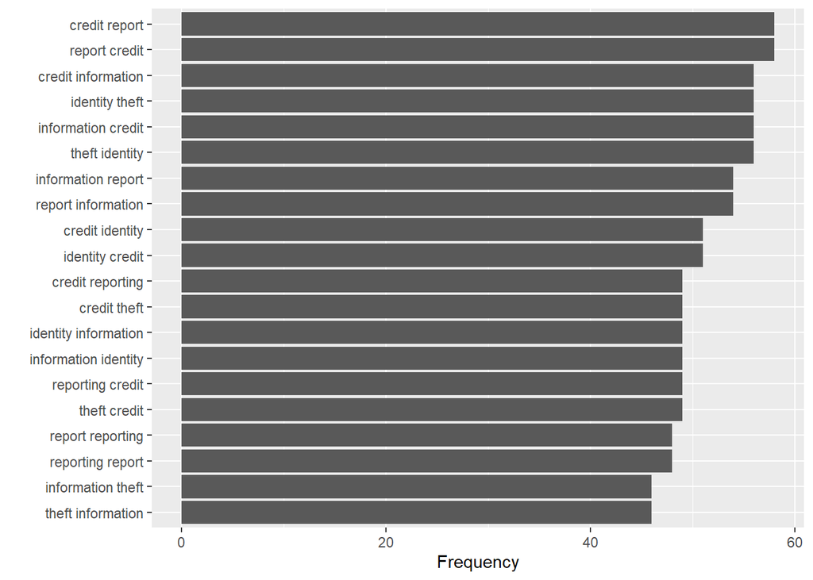

```r
# top most frequent pairs
word_pairs %>%
  head(20) %>%
  mutate(item = paste0(item1, " ", item2)) %>%
  ggplot() +
  geom_col(aes(y = fct_rev(fct_reorder(item, -n)), x = n))+
  labs(y = "", x = 'Frequency')
```

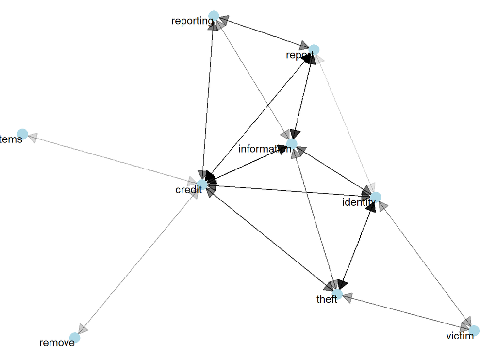

```r
# graph of word pairs
library(igraph)
pairs_graph <- word_pairs %>%
  filter(n > 40) %>%
  graph_from_data_frame()

library(ggraph)
set.seed(2024)

a <- grid::arrow(type = "closed", length = unit(.15, "inches"))

ggraph(pairs_graph, layout = "fr") +
  geom_edge_link(aes(edge_alpha = n), show.legend = FALSE,
                 arrow = a, end_cap = circle(.07, 'inches')) +
  geom_node_point(color = "lightblue", size = 5) +
  geom_node_text(aes(label = name), vjust = 1, hjust = 1) +
  theme_void()
```

```r
# ********************************************

# Pairwise Correlation

# top correlated pairs
word_cors <- df_section_words %>%
  group_by(word) %>%
  filter(n() >= 20) %>%
  pairwise_cor(item = word, feature = section, sort = TRUE)

word_cors
```

```
## # A tibble: 5,112 × 3
##    item1    item2    correlation
##    <chr>    <chr>          <dbl>
##  1 act      fair           0.937
##  2 fair     act            0.937
##  3 creditor original       0.928
##  4 original creditor       0.928
##  5 theft    identity       0.873
##  6 identity theft          0.873
##  7 business 4              0.868
##  8 4        business       0.868
##  9 days     4              0.863
## 10 4        days           0.863
## # ℹ 5,102 more rows
```

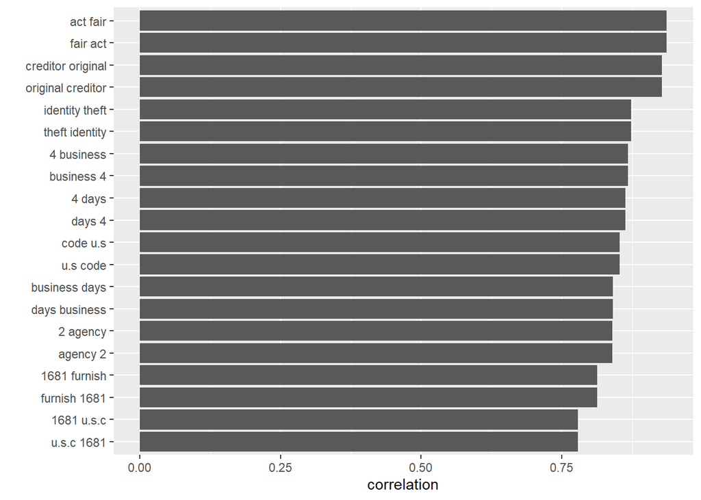

```r
word_cors %>%
  head(20) %>%
  mutate(item = paste0(item1, " ", item2)) %>%
  ggplot()+
  geom_col(aes(y = fct_rev(fct_reorder(item, -correlation)), x = correlation))+
  labs(y ='')
```

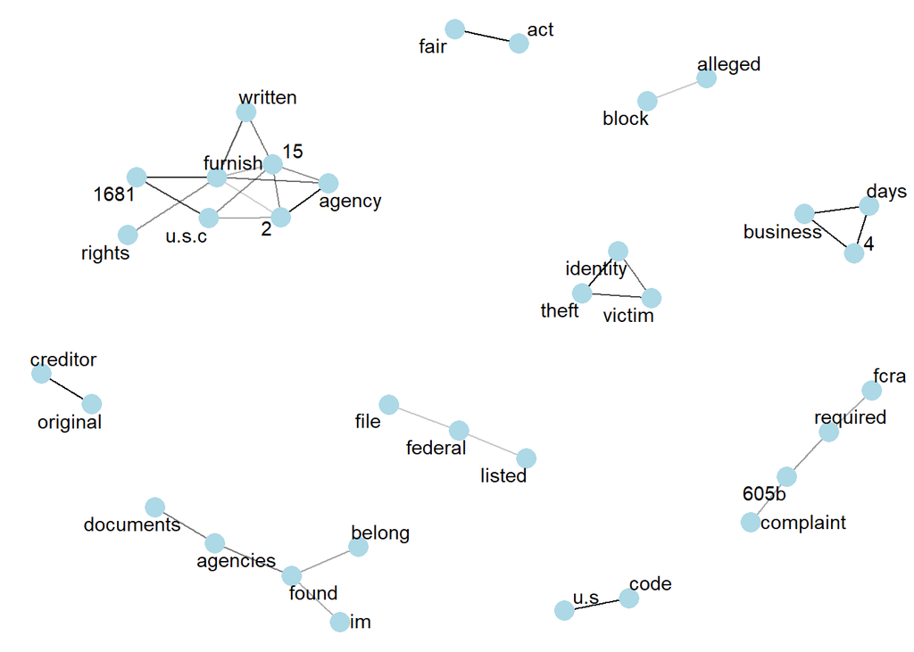

```r
# graph of the correlations
library(ggraph)
library(igraph)
set.seed(2024)

word_cors %>%
  filter(correlation > .65) %>%
  graph_from_data_frame() %>%
  ggraph(layout = "fr") +
  geom_edge_link(aes(edge_alpha = correlation), show.legend = FALSE) +
  geom_node_point(color = "lightblue", size = 5) +
  geom_node_text(aes(label = name), repel = TRUE) +
  theme_void()
```

3. tf-idf plots (Assignment 14)

Do the following:

- Define your own documents for the analysis.
- Plot the term frequency in the documents
- Plot the tf-idf in the documents.

```r
library(tidyverse)

df <- read_csv("~/Applied Analystics SAS Prog/mymath475/final_complaints.csv")
# subset the first 500 rows of the data
df = df[c(1:500),]

# OR

# a random sample of 500 rows from the data
#df = df[sample(nrow(df), 500),]

# define documents
df %>%
  group_by(`Sub-issue`) %>%
  count(sort = TRUE)
```

```
## # A tibble: 52 × 2
## # Groups:   Sub-issue [52]
##    `Sub-issue`                                                  n
##    <chr>                                                    <int>
##  1 Information belongs to someone else                         98
##  2 Reporting company used your report improperly               87
##  3 Their investigation did not fix an error on your report     72
##  4 Account status incorrect                                    28
##  5 Account information incorrect                               24
##  6 Deposits and withdrawals                                    19
##  7 Investigation took more than 30 days                        19
##  8 Credit inquiries on your report that you don't recognize    16
##  9 Was not notified of investigation status or results         12
## 10 Transaction was not authorized                              11
## # ℹ 42 more rows
```

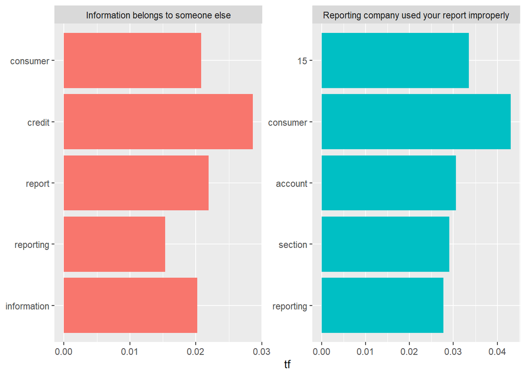

```r
# filter out data set for 2 items to analyze
df = df %>%
  select(`Sub-issue`, `Consumer complaint narrative`) %>%
  filter(`Sub-issue` %in% c('Information belongs to someone else', 'Reporting company used your report improperly')) %>%
  rename(texts = `Consumer complaint narrative`,
         document = `Sub-issue`)

# plot the term freqency for each document
stop_word2 = tibble(word = c(letters, LETTERS, "oh", 'just', 'xx', 'xxxx'))

df_words = df %>%
  unnest_tokens(input = texts, output = word) %>%
  count(document, word, sort = TRUE) %>%
  anti_join(get_stopwords()) %>%
  anti_join(stop_word2)
total_words <- df_words %>%
  group_by(document) %>%
  summarize(total = sum(n))

df_words <- left_join(df_words, total_words)
df_tf = df_words %>%
  group_by(document) %>%
  mutate(tf = n/total)

df_tf %>%
  group_by(document) %>%
  slice_max(tf, n = 5) %>%
  ungroup() %>%
  ggplot(aes(tf, fct_reorder(word, tf), fill = document)) +
  geom_col(show.legend = FALSE) +
  facet_wrap(~document, ncol = 2, scales = "free") +
  labs(x = "tf", y = NULL)
```

```r
# plot the tf-idf for each doc
df_tf_idf <- df_words %>%
  bind_tf_idf(word, document, n)

df_tf_idf
```

```
## # A tibble: 2,302 × 7
##    document                                word      n total     tf   idf tf_idf
##    <chr>                                   <chr> <int> <int>  <dbl> <dbl>  <dbl>
##  1 Reporting company used your report imp… cons…   338  7852 0.0430     0      0
##  2 Reporting company used your report imp… 15      263  7852 0.0335     0      0
##  3 Information belongs to someone else     cred…   248  8657 0.0286     0      0
##  4 Reporting company used your report imp… acco…   240  7852 0.0306     0      0
##  5 Reporting company used your report imp… sect…   228  7852 0.0290     0      0
##  6 Reporting company used your report imp… repo…   218  7852 0.0278     0      0
##  7 Reporting company used your report imp… info…   212  7852 0.0270     0      0
##  8 Information belongs to someone else     repo…   190  8657 0.0219     0      0
##  9 Reporting company used your report imp… repo…   181  7852 0.0231     0      0
## 10 Information belongs to someone else     cons…   180  8657 0.0208     0      0
## # ℹ 2,292 more rows
```

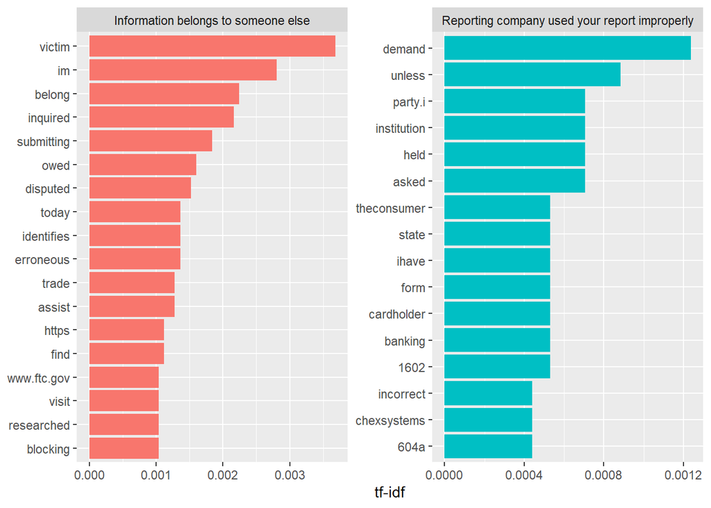

```r
library(forcats)

df_tf_idf %>%
  group_by(document) %>%
  slice_max(tf_idf, n = 15) %>%
  ungroup() %>%
  ggplot(aes(tf_idf, fct_reorder(word, tf_idf), fill = document)) +
  geom_col(show.legend = FALSE) +
  facet_wrap(~document, ncol = 2, scales = "free") +
  labs(x = "tf-idf", y = NULL)
```

4. Text Clustering (Assignment 15)

Do the following:

- Print out a sample of the Document Term Matrix using term frequency
- Print out a sample of the Document Term Matrix using tf-idf
- Cluster the words in the dataset using k-means.
- Plot the words frequency of the words in each clusters
- Plot the frequency of the part of speech of all the words in the dataset.

```r
# document term matrix- term frequency
library(tidytext)
library(tm)
library(wordcloud)
library(tidyverse)

df <- read_csv("~/Applied Analystics SAS Prog/mymath475/final_complaints.csv")
# subset the first 500 rows of the data
df = df[c(1:500),]

# OR

# a random sample of 500 rows from the data
#df = df[sample(nrow(df), 500),]

df = df %>%
  select(`Sub-issue`, `Consumer complaint narrative`) %>%
  rename(texts = `Consumer complaint narrative`,
         document = `Sub-issue`)

# create the DTM
df_tm <- df %>%
  unnest_tokens(output = word, input = texts) %>%
  anti_join(get_stopwords()) %>%
  anti_join(tibble(word = c(letters, LETTERS, "oh", 'just', 'xx', 'xxxx',  as.character(c(1:100)))))
word_freq <- df_tm %>%
  group_by(document) %>% count(word, sort = TRUE)

df_dtm <- word_freq %>%
  cast_dtm(document = document, term = word, n)

tm::inspect(df_dtm)
```

```
## <<DocumentTermMatrix (documents: 52, terms: 4463)>>
## Non-/sparse entries: 15210/216866
## Sparsity           : 93%
## Maximal term length: 21
## Weighting          : term frequency (tf)
## Sample             :
##                                                           Terms
## Docs                                                       1681 account
##   Account information incorrect                               5      80
##   Account status incorrect                                    9      74
##   Billing problem                                             0       7
##   Credit inquiries on your report that you don't recognize    9      13
##   Deposits and withdrawals                                    0      64
##   Information belongs to someone else                        29     115
##   Investigation took more than 30 days                        8      48
##   Reporting company used your report improperly             178     240
##   Their investigation did not fix an error on your report    22     127
##   Transaction was not authorized                              0      44
##                                                           Terms
## Docs                                                       accounts bank
##   Account information incorrect                                  24    4
##   Account status incorrect                                       14    0
##   Billing problem                                                 0    0
##   Credit inquiries on your report that you don't recognize        9    3
##   Deposits and withdrawals                                        4   45
##   Information belongs to someone else                            99   12
##   Investigation took more than 30 days                           27    0
##   Reporting company used your report improperly                  64    4
##   Their investigation did not fix an error on your report        58   11
##   Transaction was not authorized                                  0   31
##                                                           Terms
## Docs                                                       consumer credit
##   Account information incorrect                                  40     71
##   Account status incorrect                                       30     83
##   Billing problem                                                 2      5
##   Credit inquiries on your report that you don't recognize       14     36
##   Deposits and withdrawals                                        2      3
##   Information belongs to someone else                           180    248
##   Investigation took more than 30 days                           16     55
##   Reporting company used your report improperly                 338    147
```

[output cut: 11 more lines]

```
##   Reporting company used your report improperly                    212    181
##   Their investigation did not fix an error on your report          144    135
##   Transaction was not authorized                                     2      1
##                                                           Terms
## Docs                                                       reporting section
##   Account information incorrect                                   53       8
##   Account status incorrect                                        31      10
##   Billing problem                                                  0       0
##   Credit inquiries on your report that you don't recognize         8       4
##   Deposits and withdrawals                                         3       0
##   Information belongs to someone else                            133      81
##   Investigation took more than 30 days                            16      21
##   Reporting company used your report improperly                  218     228
##   Their investigation did not fix an error on your report         92      49
##   Transaction was not authorized                                   0       0
```

```r
# DTM- tf-idf
df_dtm <- weightTfIdf(df_dtm)

tm::inspect(df_dtm)
```

```
## <<DocumentTermMatrix (documents: 52, terms: 4463)>>
## Non-/sparse entries: 15210/216866
## Sparsity           : 93%
## Maximal term length: 21
## Weighting          : term frequency - inverse document frequency (normalized) (tf-idf)
## Sample             :
##                                                 Terms
## Docs                                                 account       bank
##   Account opened without my consent or knowledge 0.024661415 0.02806434
##   Billing problem                                0.003197120 0.00000000
##   Deficiency balance after repossession          0.000000000 0.00000000
##   Denied loan                                    0.000000000 0.00000000
##   Didn't receive terms that were advertised      0.010020130 0.00000000
##   Fraudulent loan                                0.000000000 0.00000000
##   Keep getting calls about your loan             0.000000000 0.00000000
##   Problem lowering your monthly payments         0.000000000 0.00000000
##   Problem with your payment plan                 0.000000000 0.00000000
##   Received bad information about your loan       0.002993819 0.00000000
##                                                 Terms
## Docs                                                  closed      credit
##   Account opened without my consent or knowledge 0.003494326 0.001120973
##   Billing problem                                0.000000000 0.002283657
##   Deficiency balance after repossession          0.000000000 0.010300413
##   Denied loan                                    0.000000000 0.025395846
##   Didn't receive terms that were advertised      0.000000000 0.003340043
##   Fraudulent loan                                0.000000000 0.009092340
##   Keep getting calls about your loan             0.000000000 0.000000000
##   Problem lowering your monthly payments         0.000000000 0.000000000
##   Problem with your payment plan                 0.000000000 0.001698915
##   Received bad information about your loan       0.000000000 0.000000000
##                                                 Terms
## Docs                                                 fargo    interest
##   Account opened without my consent or knowledge 0.1039938 0.000000000
##   Billing problem                                0.0000000 0.021689431
##   Deficiency balance after repossession          0.0000000 0.000000000
##   Denied loan                                    0.0000000 0.030923261
##   Didn't receive terms that were advertised      0.0000000 0.000000000
##   Fraudulent loan                                0.0000000 0.000000000
##   Keep getting calls about your loan             0.0000000 0.048914976
##   Problem lowering your monthly payments         0.0000000 0.109362751
```

[output cut: 11 more lines]

```
##   Problem lowering your monthly payments                   0 0.00000000
##   Problem with your payment plan                           0 0.00000000
##   Received bad information about your loan                 0 0.07528312
##                                                 Terms
## Docs                                                   report     wells
##   Account opened without my consent or knowledge 0.0000000000 0.1039938
##   Billing problem                                0.0007381852 0.0000000
##   Deficiency balance after repossession          0.0055492946 0.0000000
##   Denied loan                                    0.0000000000 0.0000000
##   Didn't receive terms that were advertised      0.0000000000 0.0000000
##   Fraudulent loan                                0.0000000000 0.0000000
##   Keep getting calls about your loan             0.0000000000 0.0000000
##   Problem lowering your monthly payments         0.0000000000 0.0000000
##   Problem with your payment plan                 0.0027458447 0.0000000
##   Received bad information about your loan       0.0000000000 0.0000000
```

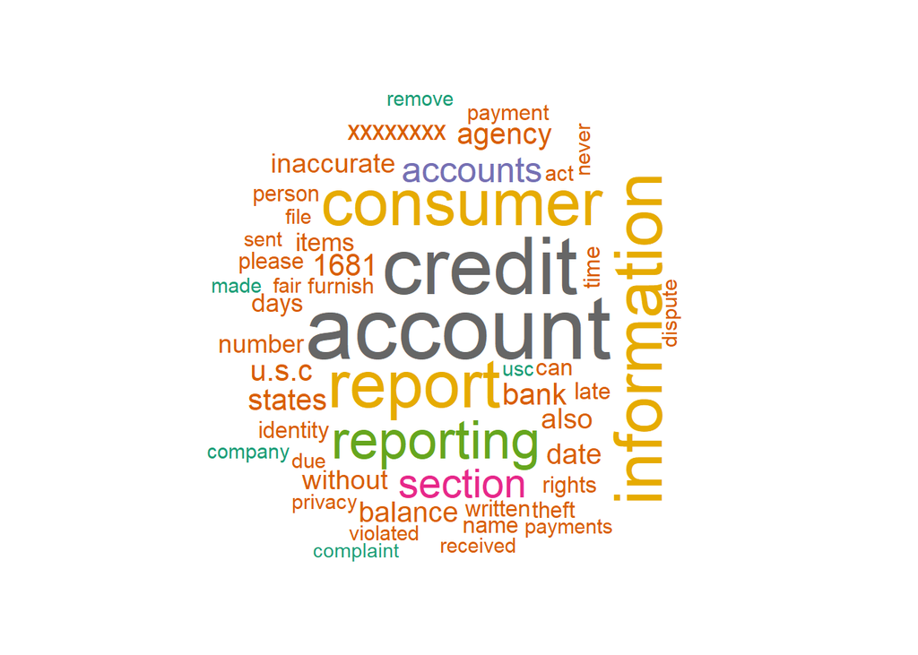

```r
# *****************************************

# Clustering

# transpose data so terms are rows of data
# df_dtm <- removeSparseTerms(df_dtm, 0.5)
kmeans.data <- as.matrix(t(df_dtm))

kfit <- kmeans(kmeans.data, 3)

# plot word cloud
df %>%
  unnest_tokens(input = texts, output = word) %>%
  anti_join(get_stopwords()) %>%
  anti_join(tibble(word = c(letters, LETTERS, "oh", 'just', 'xx', 'xxxx',  as.character(c(1:100))))) %>%
  count(word, sort = TRUE) %>%
  with(wordcloud(word, n, random.order = FALSE,
                 max.words = 50, colors=brewer.pal(8,"Dark2")))
```

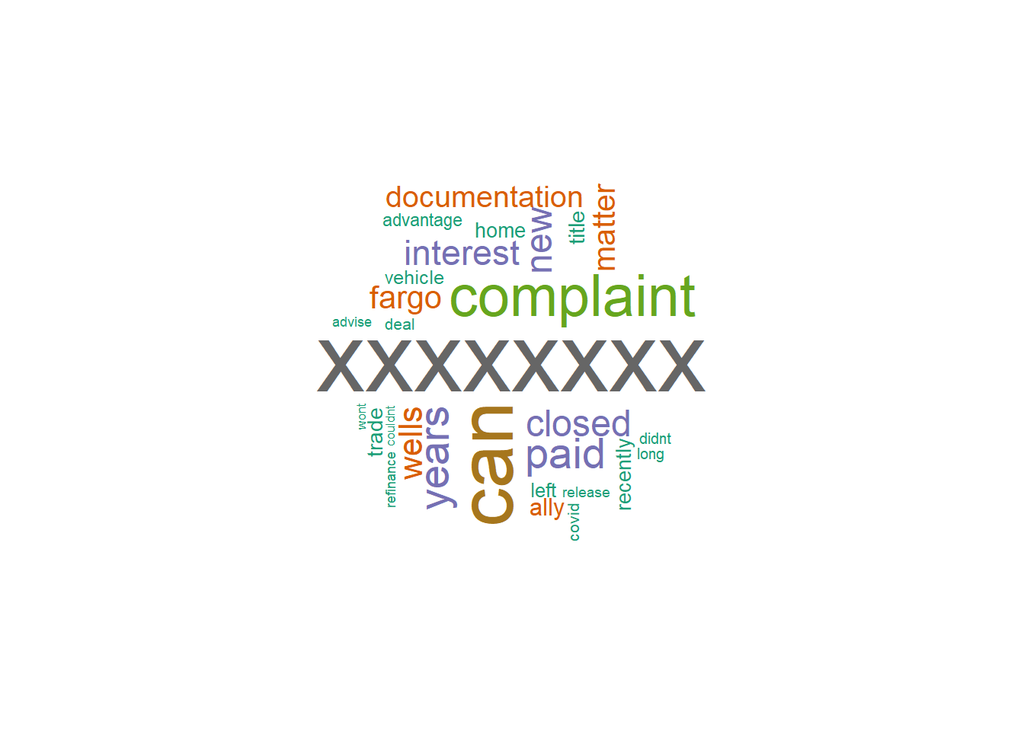

```r
# plot cluster 1
k = 1

cluster = names(kfit$cluster)[kfit$cluster==k]
cluster = as_tibble(cluster) %>%
  rename(word = value)

cluster = word_freq <- df_tm %>%
  count(word, sort = TRUE) %>%
  inner_join(cluster, by = 'word')

library(wordcloud)
set.seed(2024)
cluster %>% with(wordcloud(word, n, max.words = 50, random.order = FALSE, rot.per = 0.35,
    colors = brewer.pal(8, "Dark2")))
```

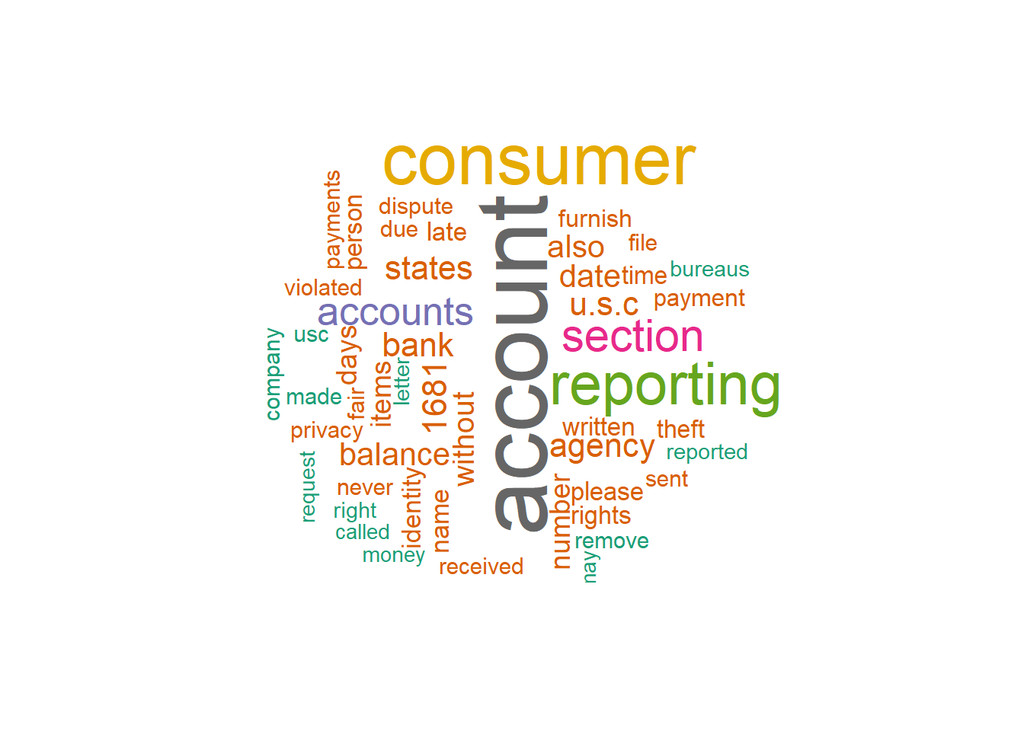

```r
# plot cluster 2
k = 2

cluster = names(kfit$cluster)[kfit$cluster==k]
cluster = as_tibble(cluster) %>%
  rename(word = value)

cluster = word_freq <- df_tm %>%
  count(word, sort = TRUE) %>%
  inner_join(cluster, by = 'word')

library(wordcloud)
set.seed(2024)
cluster %>% with(wordcloud(word, n, max.words = 50, random.order = FALSE, rot.per = 0.35,
    colors = brewer.pal(8, "Dark2")))
```

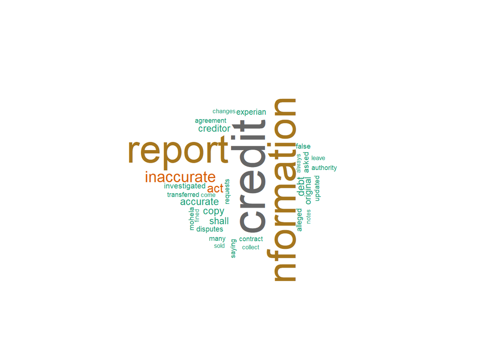

```r
# plot cluster 3
k = 3

cluster = names(kfit$cluster)[kfit$cluster==k]
cluster = as_tibble(cluster) %>%
  rename(word = value)

cluster = word_freq <- df_tm %>%
  count(word, sort = TRUE) %>%
  inner_join(cluster, by = 'word')

library(wordcloud)
set.seed(2024)
cluster %>% with(wordcloud(word, n, max.words = 50, random.order = FALSE, rot.per = 0.35,
    colors = brewer.pal(8, "Dark2")))
```

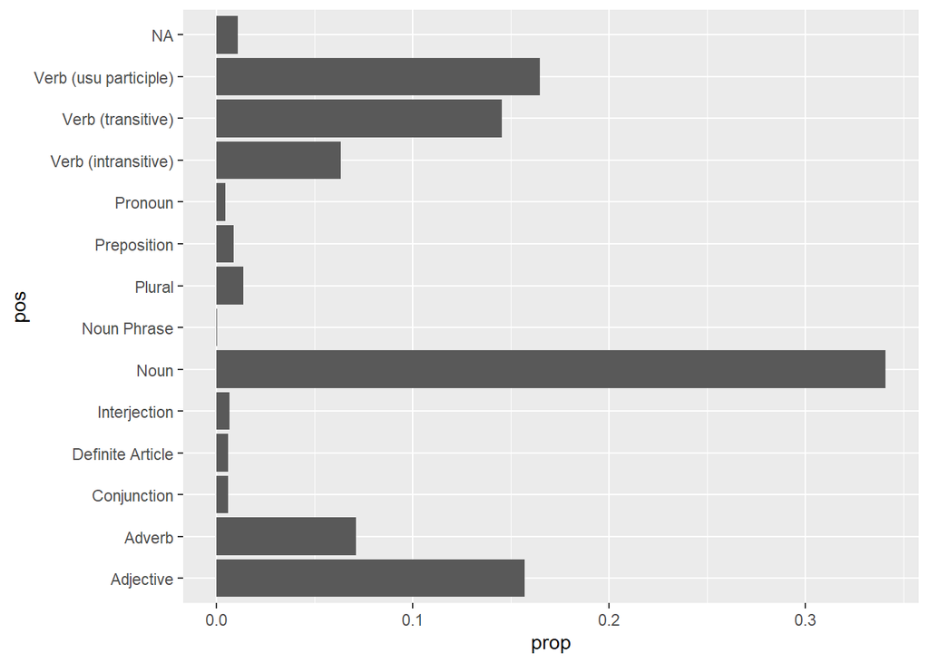

```r
# *******************************************

# Part of Speech

# map words into its part of speech (noun, ver, etc.)
library(tidyverse)
library(tidytext)
library(tm)
library(wordcloud)

df <- read_csv("~/Applied Analystics SAS Prog/mymath475/final_complaints.csv")
# subset the first 500 rows of the data
df = df[c(1:500),]

# OR

# a random sample of 500 rows from the data
#df = df[sample(nrow(df), 500),]

df = df %>%
  select(`Sub-issue`, `Consumer complaint narrative`) %>%
  rename(texts = `Consumer complaint narrative`,
         document = `Sub-issue`)

stop_word2 = tibble(word = c(letters, LETTERS, "oh", 'just', 'xx', 'xxxx'))

df %>%
    unnest_tokens(input = texts, output = word) %>%
    count(word, sort = TRUE) %>%
    anti_join(get_stopwords()) %>%
    anti_join(stop_word2) %>%
    inner_join(parts_of_speech) %>%                   # join POS
    count(pos) %>%                                    # count
    mutate(prop=n/sum(n)) %>%
    slice_max(prop, n = 15) %>%
    ggplot()+geom_col(aes(y = pos, x = prop), position = 'dodge')
```

```r
# doc based parts of speech
df <- read_csv("~/Applied Analystics SAS Prog/mymath475/final_complaints.csv")
```

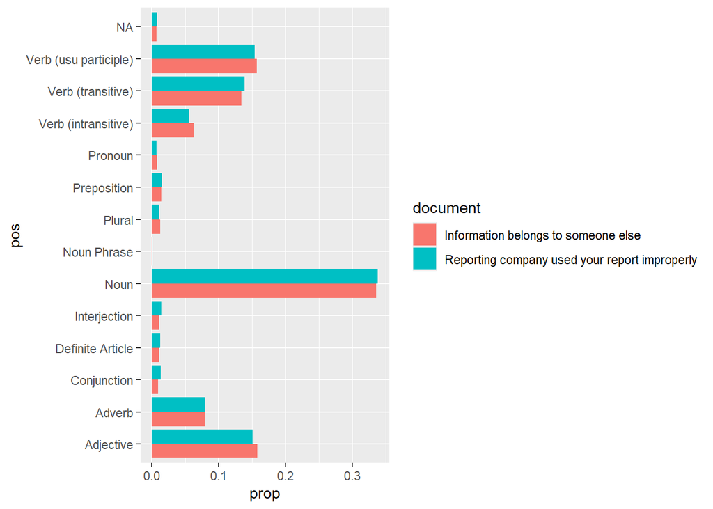

```r
# subset the first 500 rows of the data
df = df[c(1:500),]

# OR

# a random sample of 500 rows from the data
#df = df[sample(nrow(df), 500),]

df = df %>%
  select(`Sub-issue`, `Consumer complaint narrative`) %>%
  rename(texts = `Consumer complaint narrative`,
         document = `Sub-issue`)

df <- df %>%
  filter(grepl("Information belongs to someone else|Reporting company used your report improperly", document))

stop_word2 = tibble(word = c(letters, LETTERS, "oh", 'just', 'xx', 'xxxx'))

df %>%
    unnest_tokens(input = texts, output = word) %>%
    group_by(document) %>%
    count(document, word, sort = TRUE) %>%
    anti_join(get_stopwords()) %>%
    anti_join(stop_word2) %>%
    inner_join(parts_of_speech) %>%                   # join POS
    count(pos) %>%                                    # count
    mutate(prop=n/sum(n)) %>%
    slice_max(prop, n = 15) %>%
    ggplot()+geom_col(aes(y = pos, x = prop, fill =  document), position = 'dodge')
```